# Model Selection for DCCC Data with Explanations

2022-03-25

First we need to upload the data. So:

```r
df_dc = read.csv('E:/2022/Freelance/Jobs/001-25/data-dc.csv', header=T)
df_dc = data.frame(time=df_dc$Time..hours., fails=df_dc$Number.of.failures)
```

So we created a new data frame with proper column names. To see what it looks like, we can print the data frame:

```r
df_dc
```

```
##    time fails
## 1  2000     0
## 2  2090     1
## 3  2250     2
## 4  2300     0
## 5  2420     1
## 6  2500     2
## 7  2530     1
## 8  2600     1
## 9  2900     1
## 10 2970     1
## 11 3000     1
## 12 3120     1
## 13 3200     2
## 14 3331     1
```

[output cut: 29 more lines]

In the second column the number of failures for each time points is recorded. In order to have a complete data set we need to create repetitions of those time points with the frequency of the number of failures. Therefore we repeat each time points relative to their respective number of failures.

```r
time_rep = rep(df_dc$time, df_dc$fails)
```

Now we create an empty data frame to hold the information of the distributions that we are going to check.

```r
info_df = data.frame(model=NA, method=NA,Log_likelihood=NA, AIC=NA)
```

In this data frame we have a *model* column which stores the name of the distribution (weibull, gamma, log-normal, beta), a *method* column which stores the method of optimization that is going to be used (mle, mme, qme, mge), and *log-likelihood* and *aic* columns.

Before doing anything, we need to call a library called *fitdistrplus* that will do this process for us. After that we can start checking different distributions with the `fitdist` function.

```r
library(fitdistrplus)
```

# Weibull Distribution

## Weibull with mle

our first method is mle (maximum likelihood estimation):

```r
fit_wei_mle = fitdist(time_rep, 'weibull', method='mle')
info_df[1, ] = c('weibull','MLE',fit_wei_mle$loglik, fit_wei_mle$aic)
```

We can use the `summary()` and `plot()` over this fitted weibull distribution to see its characteristics and how it fits the data using plots.

```r
summary(fit_wei_mle)
```

```
## Fitting of the distribution ' weibull ' by maximum likelihood
## Parameters :
##          estimate  Std. Error
## shape    4.153542   0.4414425
## scale 4882.600763 159.6242782
## Loglikelihood:  -511.6616   AIC:  1027.323   BIC:  1031.512
## Correlation matrix:
##           shape     scale
## shape 1.0000000 0.3103081
## scale 0.3103081 1.0000000
```

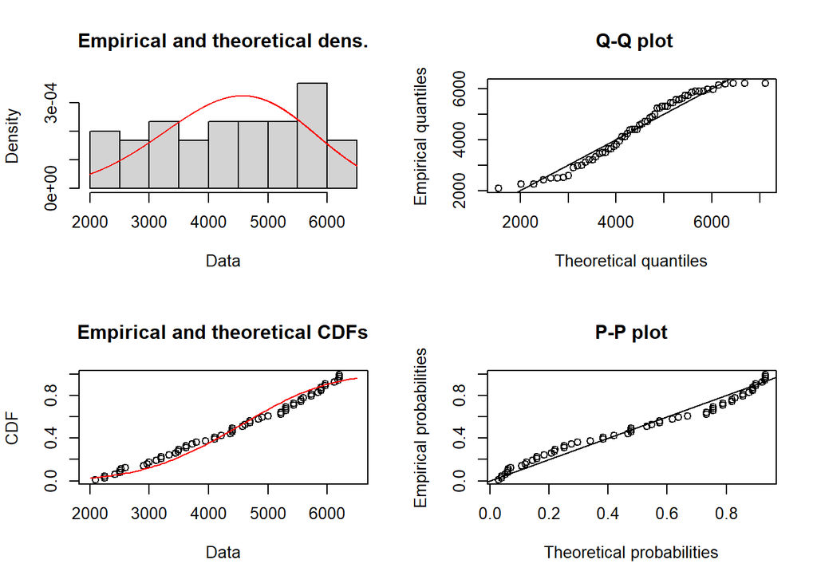

```r
plot(fit_wei_mle)
```

Now we do the same for all other methods and distributions

## Weibull with mme

For the moment matching estimation method we need the moment order of the parameters and a moment function and the `actuar` library for the weibull distribution.

```r
library(actuar)
memp <- function(x, order) mean(x^order)
fit_wei_mme = fitdist(time_rep, 'weibull', method='mme', order=c(1,2), memp=memp)
summary(fit_wei_mme)
```

[output not shown]

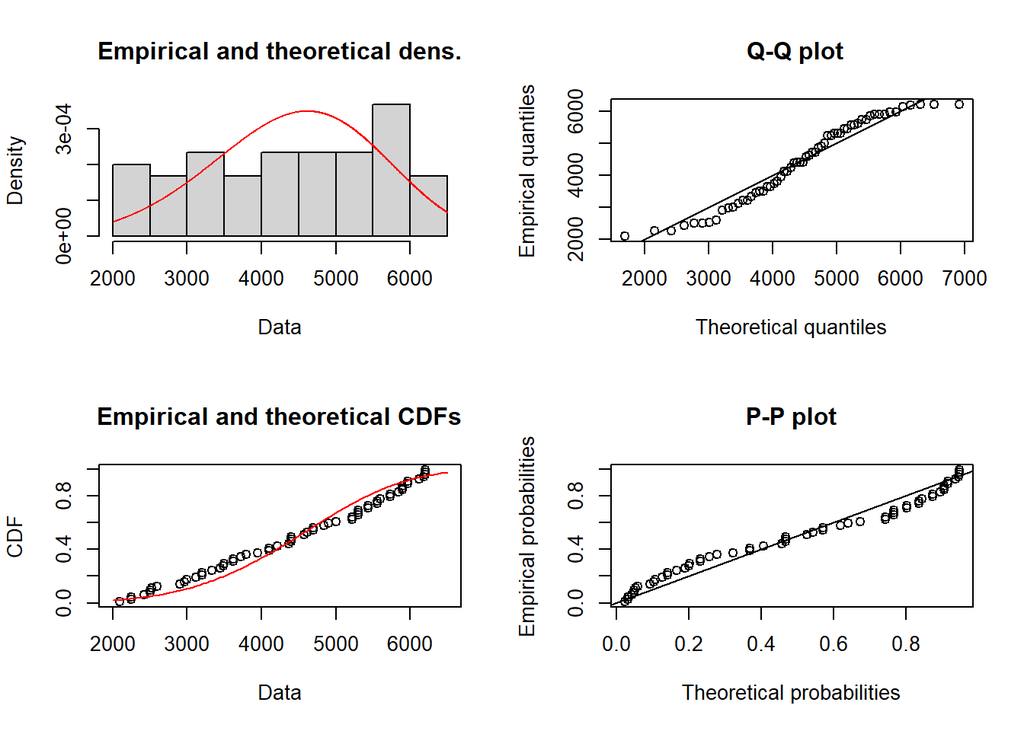

```r
plot(fit_wei_mme)
```

```r
info_df[2, ] = c('weibull','MME',fit_wei_mme$loglik, fit_wei_mme$aic)
```

For the qme method, we need probabilities to check for their quantiles which is stored in the `probs` argument. ## Weibull with qme

```r
fit_wei_qme = fitdist(time_rep, 'weibull', method='qme', probs=c(0.5,0.5))
summary(fit_wei_qme)
```

```
## Fitting of the distribution ' weibull ' by matching quantiles
## Parameters :
##          estimate
## shape    4.175793
## scale 4896.443266
## Loglikelihood:  -511.6656   AIC:  1027.331   BIC:  1031.52
```

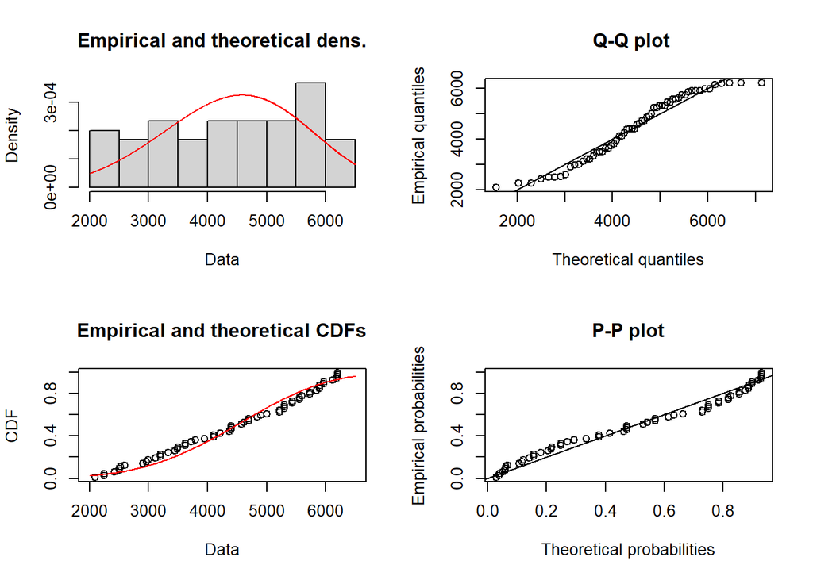

```r
plot(fit_wei_qme)
```

```r
info_df[3, ] = c('weibull','QME',fit_wei_qme$loglik, fit_wei_qme$aic)
```

For the maximum goodness-of-fit estimation method we need to add the `gof` argument which stores the goodness-of-fit distance. ## Weibull with gme (KS)

```r
fit_wei_mge = fitdist(time_rep, 'weibull', method='mge', gof='KS')
summary(fit_wei_mge)
```

```
## Fitting of the distribution ' weibull ' by maximum goodness-of-fit
## Parameters :
##          estimate
## shape    4.016722
## scale 4968.956964
## Loglikelihood:  -511.9126   AIC:  1027.825   BIC:  1032.014
```

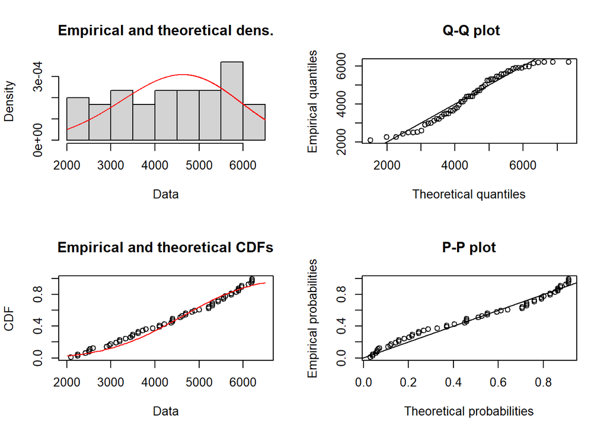

```r
plot(fit_wei_mge)
```

```r
info_df[4, ] = c('weibull','MGE KS',fit_wei_mge$loglik, fit_wei_mge$aic)
```

## Weibull with gme (CvM)

```r
fit_wei_mge.2 = fitdist(time_rep, 'weibull', method='mge', gof='CvM')
summary(fit_wei_mge.2)
```

```
## Fitting of the distribution ' weibull ' by maximum goodness-of-fit
## Parameters :
##          estimate
## shape    3.504734
## scale 4963.702212
## Loglikelihood:  -513.2272   AIC:  1030.454   BIC:  1034.643
```

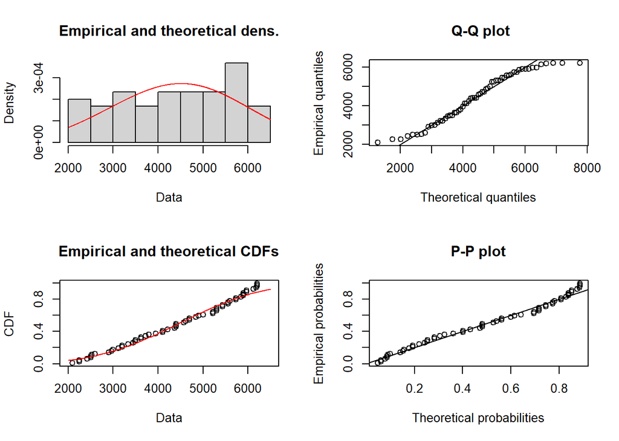

```r
plot(fit_wei_mge.2)
```

```r
info_df[5, ] = c('weibull','MGE CvM',fit_wei_mge.2$loglik, fit_wei_mge.2$aic)
```

## Weibull with gme (AD)

```r
fit_wei_mge.3 = fitdist(time_rep, 'weibull', method='mge', gof='AD')
summary(fit_wei_mge.3)
```

```
## Fitting of the distribution ' weibull ' by maximum goodness-of-fit
## Parameters :
##          estimate
## shape    3.645045
## scale 4930.085430
## Loglikelihood:  -512.566   AIC:  1029.132   BIC:  1033.321
```

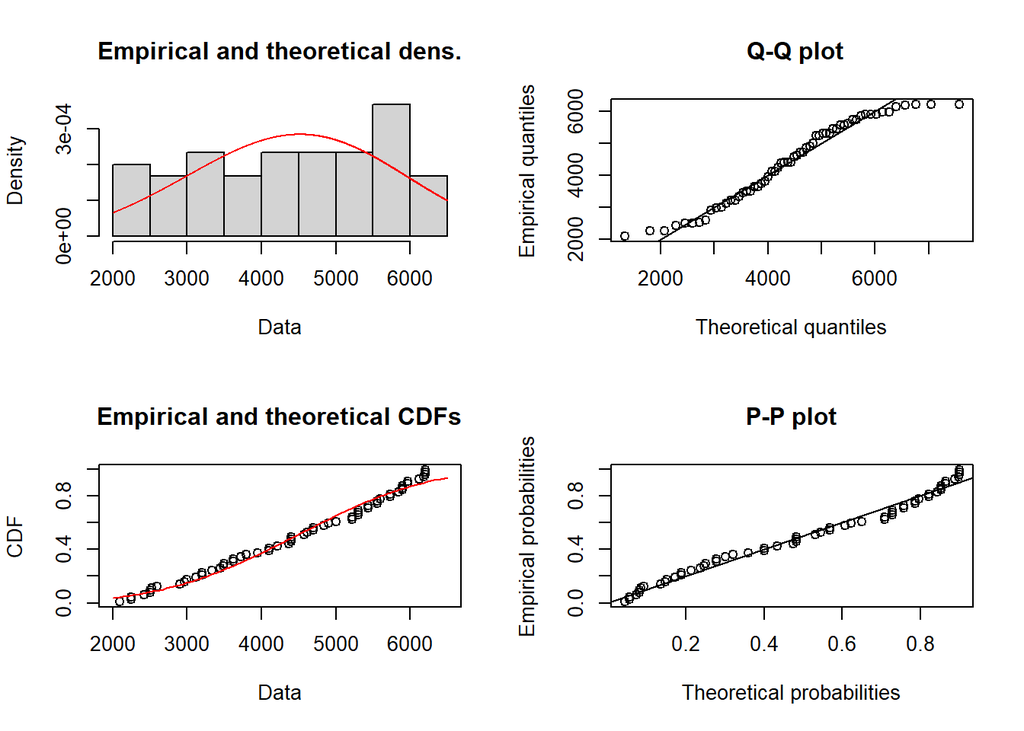

```r
plot(fit_wei_mge.3)
```

```r
info_df[6, ] = c('weibull','MGE AD',fit_wei_mge.3$loglik, fit_wei_mge.3$aic)
```

Now we can do this whole process for the other 3 distributions.

# Gamma Distribution

```r
# MLE
fit_gam_mle = fitdist(time_rep, 'gamma', method='mle')
summary(fit_gam_mle)
```

```
## Fitting of the distribution ' gamma ' by maximum likelihood
## Parameters :
##           estimate   Std. Error
## shape 11.198686499 0.7501356924
## rate   0.002534637 0.0001387929
## Loglikelihood:  -514.4577   AIC:  1032.915   BIC:  1037.104
## Correlation matrix:
##           shape      rate
## shape 1.0000000 0.8263694
## rate  0.8263694 1.0000000
```

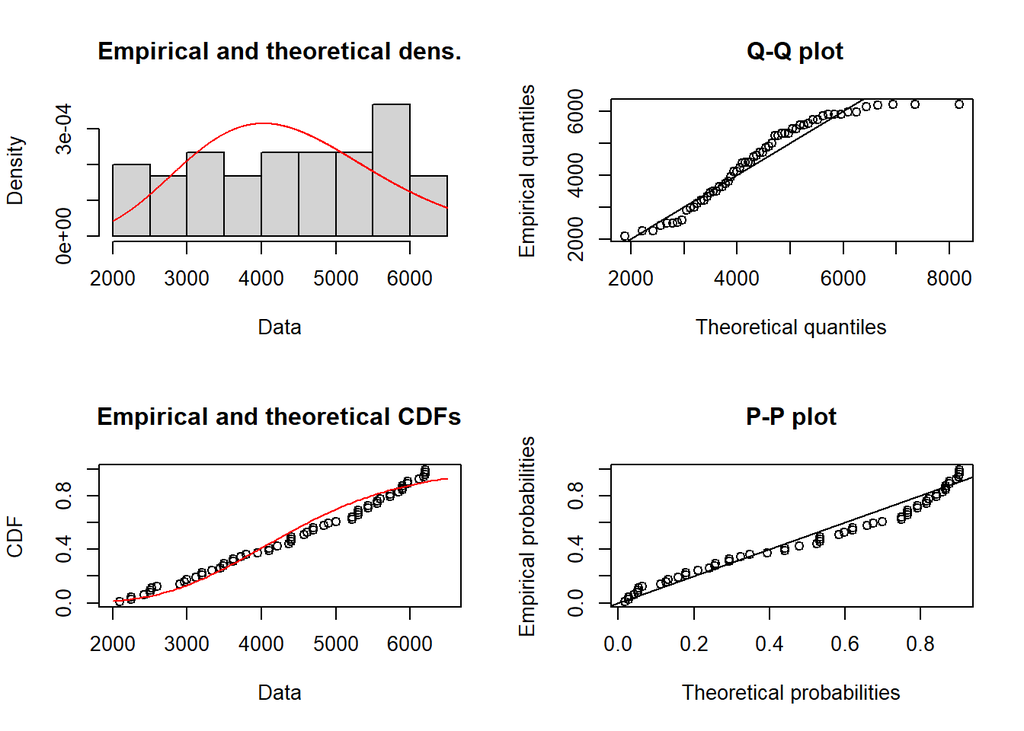

```r
plot(fit_gam_mle)
```

```r
info_df[7, ] = c('gamma','MLE',fit_gam_mle$loglik, fit_gam_mle$aic)

# MME
fit_gam_mme = fitdist(time_rep, 'gamma', method='mme')
summary(fit_gam_mme)
```

```
## Fitting of the distribution ' gamma ' by matching moments
## Parameters :
##           estimate
## shape 12.516363697
## rate   0.002832899
## Loglikelihood:  -514.6575   AIC:  1033.315   BIC:  1037.504
```

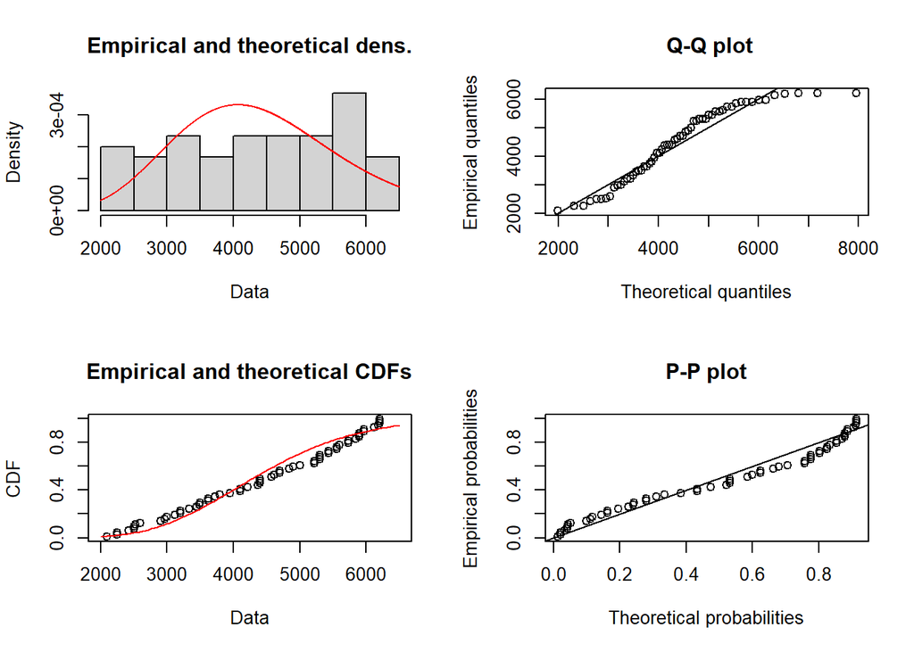

```r
plot(fit_gam_mme)
```

```r
info_df[8, ] = c('gamma','MME',fit_gam_mme$loglik, fit_gam_mme$aic)

# QME
fit_gam_qme = fitdist(time_rep, 'gamma', method='qme', probs=c(0.5,0.5))
summary(fit_gam_qme)
```

```
## Fitting of the distribution ' gamma ' by matching quantiles
## Parameters :
##           estimate
## shape 12.905459037
## rate   0.002803502
## Loglikelihood:  -515.4287   AIC:  1034.857   BIC:  1039.046
```

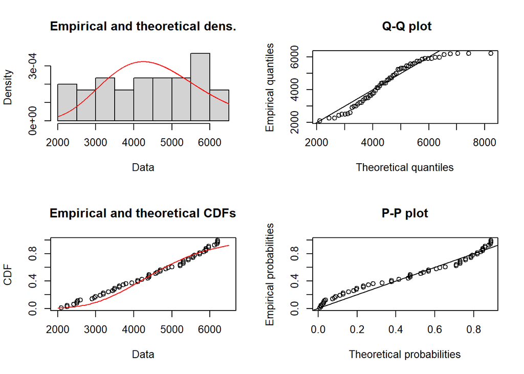

```r
plot(fit_gam_qme)
```

```r
info_df[9, ] = c('gamma','QME',fit_gam_qme$loglik, fit_gam_qme$aic)

# MGE
fit_gam_mge = fitdist(time_rep, 'gamma', method='mge', gof='KS')
summary(fit_gam_mge)
```

```
## Fitting of the distribution ' gamma ' by maximum goodness-of-fit
## Parameters :
##           estimate
## shape 13.241950130
## rate   0.002897282
## Loglikelihood:  -515.3694   AIC:  1034.739   BIC:  1038.928
```

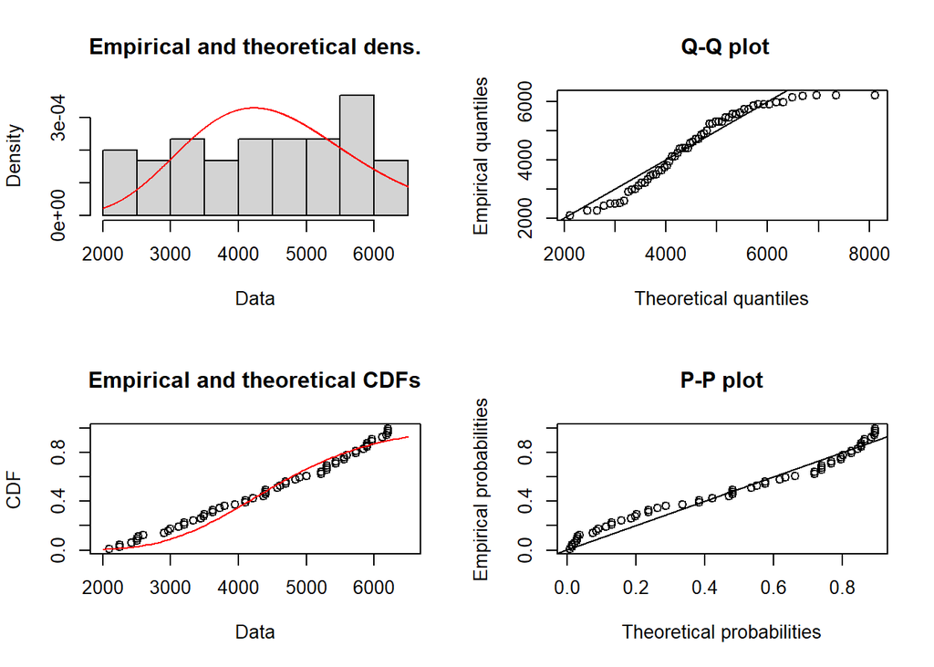

```r
plot(fit_gam_mge)
```

```r
info_df[10, ] = c('gamma','MGE KS',fit_gam_mge$loglik, fit_gam_mge$aic)

fit_gam_mge.3 = fitdist(time_rep, 'gamma', method='mge', gof='AD')
summary(fit_gam_mge.3)
```

```
## Fitting of the distribution ' gamma ' by maximum goodness-of-fit
## Parameters :
##          estimate
## shape 9.246002430
## rate  0.002050458
## Loglikelihood:  -515.1035   AIC:  1034.207   BIC:  1038.396
```

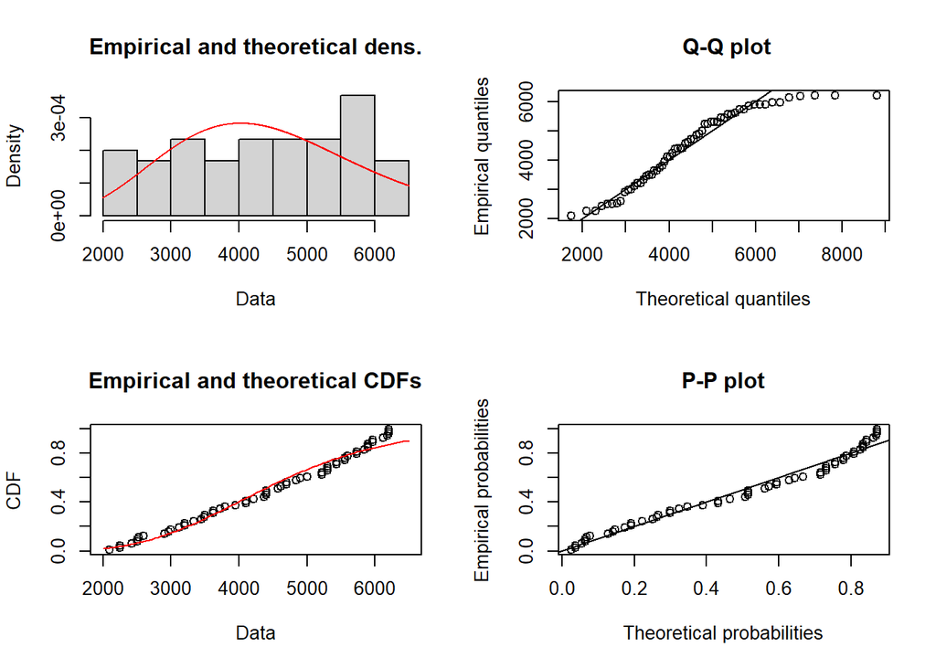

```r
plot(fit_gam_mge.3)
```

```r
info_df[11, ] = c('gamma','MGE AD',fit_gam_mge.3$loglik, fit_gam_mge.3$aic)
```

The only exception here, is that when we use CvM goodness-of-fit distance it cannot perform the optimization process and returns and error. Therefore it is not mentioned here.

# Log-normal Distribution

```r
# MLE
fit_lnorm_mle = fitdist(time_rep, 'lnorm', method='mle')
summary(fit_lnorm_mle)
```

```
## Fitting of the distribution ' lnorm ' by maximum likelihood
## Parameters :
##         estimate Std. Error
## meanlog 8.348160 0.04023759
## sdlog   0.311679 0.02845095
## Loglikelihood:  -516.079   AIC:  1036.158   BIC:  1040.347
## Correlation matrix:
##         meanlog sdlog
## meanlog       1     0
## sdlog         0     1
```

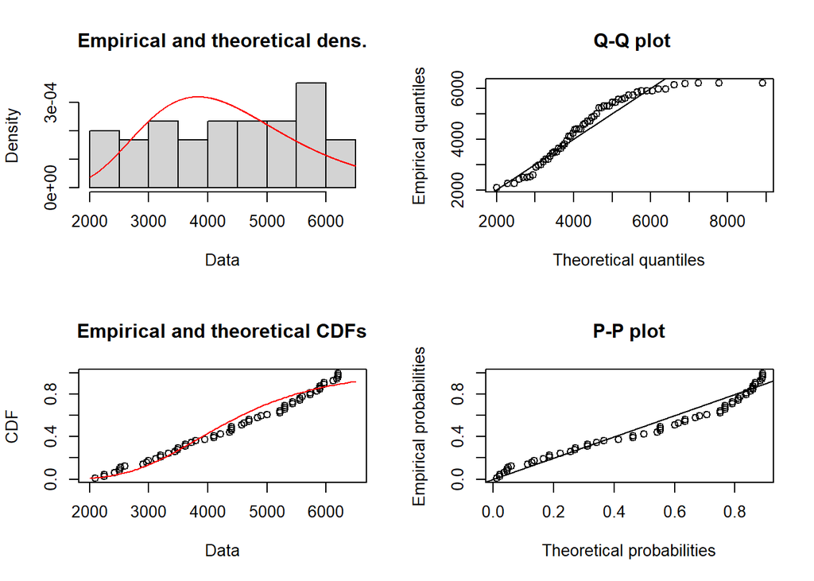

```r
plot(fit_lnorm_mle)
```

```r
info_df[12, ] = c('lnorm','MLE',fit_lnorm_mle$loglik, fit_lnorm_mle$aic)

# MME
fit_lnorm_mme = fitdist(time_rep, 'lnorm', method='mme')
summary(fit_lnorm_mme)
```

```
## Fitting of the distribution ' lnorm ' by matching moments
## Parameters :
##          estimate
## meanlog 8.3550593
## sdlog   0.2772439
## Loglikelihood:  -516.9881   AIC:  1037.976   BIC:  1042.165
```

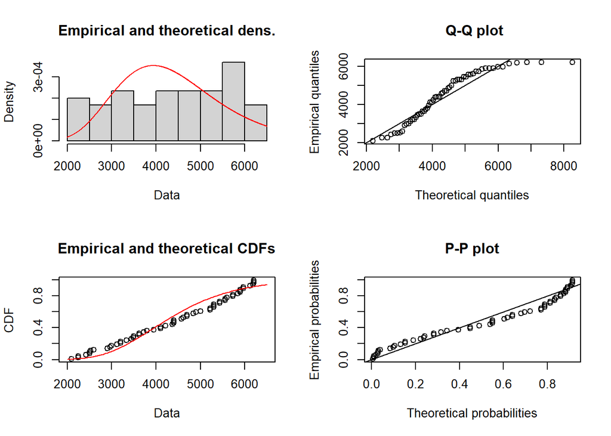

```r
plot(fit_lnorm_mme)
```

```r
info_df[13, ] = c('lnorm','MME',fit_lnorm_mme$loglik, fit_lnorm_mme$aic)

# QME
fit_lnorm_qme = fitdist(time_rep, 'lnorm', method='qme', probs=c(0.5,0.5))
summary(fit_lnorm_qme)
```

```
## Fitting of the distribution ' lnorm ' by matching quantiles
## Parameters :
##         estimate
## meanlog 8.408496
## sdlog   1.317153
## Loglikelihood:  -574.297   AIC:  1152.594   BIC:  1156.783
```

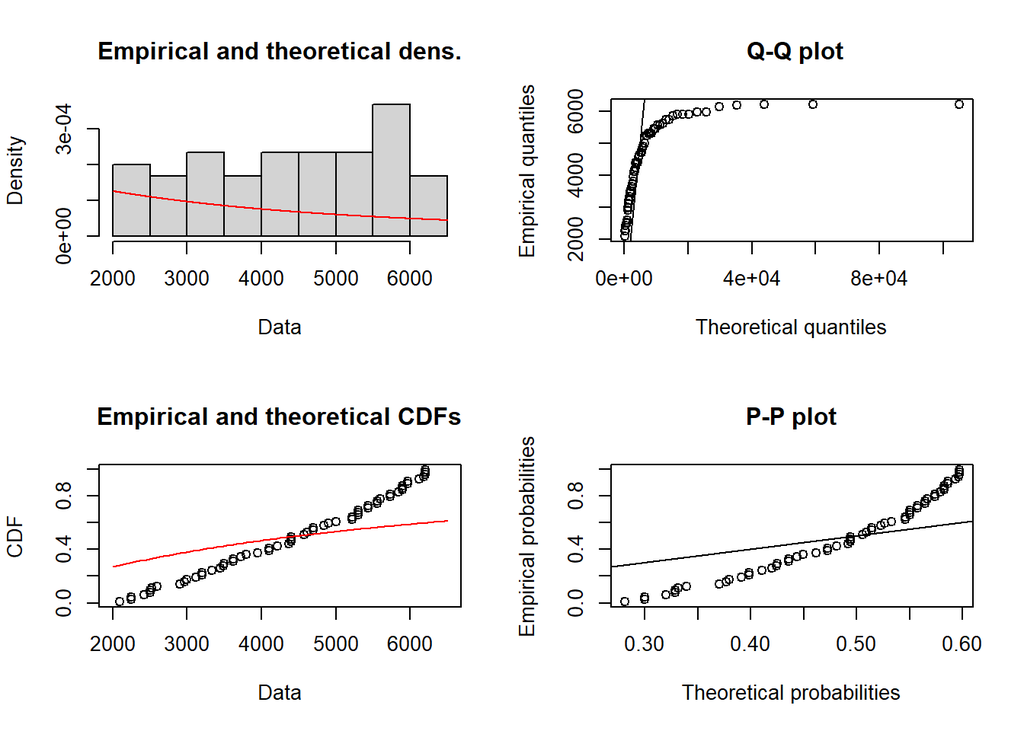

```r
plot(fit_lnorm_qme)
```

```r
info_df[14, ] = c('lnorm','QME',fit_lnorm_qme$loglik, fit_lnorm_qme$aic)

# MGE
fit_lnorm_mge = fitdist(time_rep, 'lnorm', method='mge', gof='KS')
summary(fit_lnorm_mge)
```

```
## Fitting of the distribution ' lnorm ' by maximum goodness-of-fit
## Parameters :
##          estimate
## meanlog 8.3927469
## sdlog   0.2773336
## Loglikelihood:  -517.7399   AIC:  1039.48   BIC:  1043.668
```

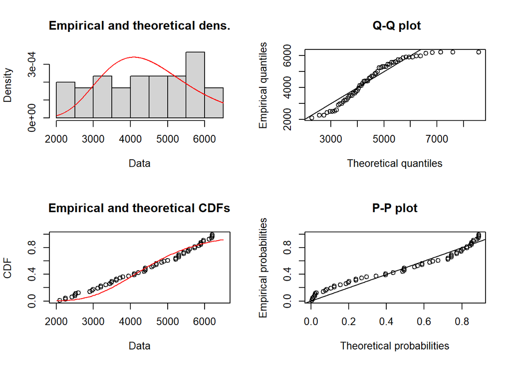

```r
plot(fit_lnorm_mge)
```

```r
info_df[15, ] = c('lnorm','MGE KS',fit_lnorm_mge$loglik, fit_lnorm_mge$aic)

fit_lnorm_mge.2 = fitdist(time_rep, 'lnorm', method='mge', gof='CvM')
summary(fit_lnorm_mge.2)
```

```
## Fitting of the distribution ' lnorm ' by maximum goodness-of-fit
## Parameters :
##          estimate
## meanlog 8.3797862
## sdlog   0.3389694
## Loglikelihood:  -516.7402   AIC:  1037.48   BIC:  1041.669
```

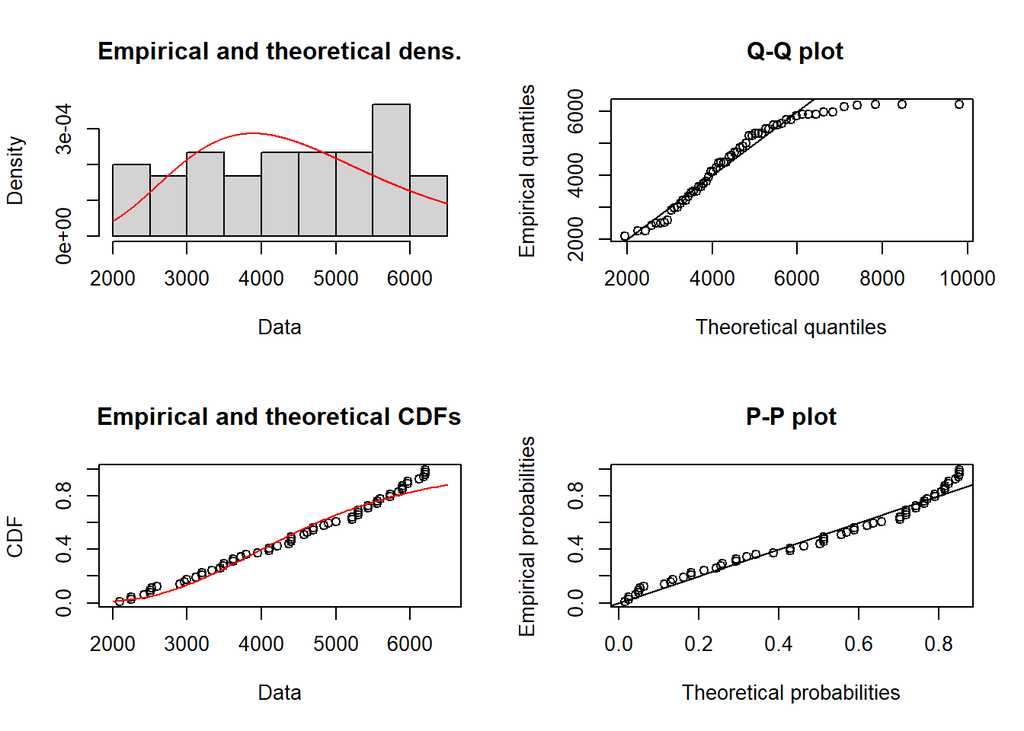

```r
plot(fit_lnorm_mge.2)
```

```r
info_df[16, ] = c('lnorm','MGE CvM',fit_lnorm_mge.2$loglik, fit_lnorm_mge.2$aic)

fit_lnorm_mge.3 = fitdist(time_rep, 'lnorm', method='mge', gof='AD')
summary(fit_lnorm_mge.3)
```

```
## Fitting of the distribution ' lnorm ' by maximum goodness-of-fit
## Parameters :
##          estimate
## meanlog 8.3659692
## sdlog   0.3428589
## Loglikelihood:  -516.6723   AIC:  1037.345   BIC:  1041.533
```

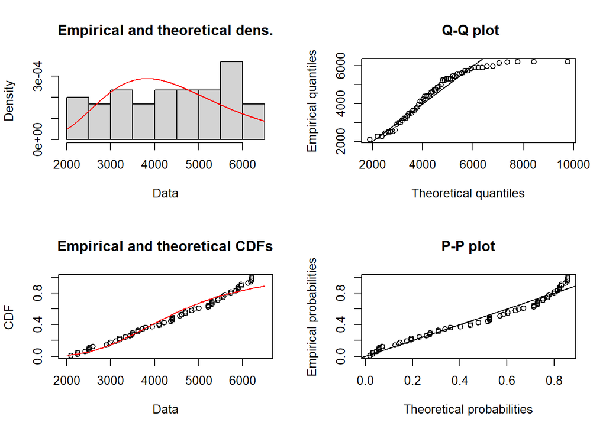

```r
plot(fit_lnorm_mge.3)
```

```r
info_df[17, ] = c('lnorm','MGE AD',fit_lnorm_mge.3$loglik, fit_lnorm_mge.3$aic)
```

# Beta Distribution

For the beta distribution we need to make some adjustments since this distribution needs our data to be within [0-1] interval. We can achieve this by simply dividing our time points to 10000.

```r
time_rep_beta = time_rep/10000
```

Now we can check different methods for this distribution.

```r
# MLE
fit_beta_mle = fitdist(time_rep_beta, 'beta', method='mle')
summary(fit_beta_mle)
```

```
## Fitting of the distribution ' beta ' by maximum likelihood
## Parameters :
##        estimate Std. Error
## shape1 6.678513   1.195520
## shape2 8.466987   1.527763
## Loglikelihood:  40.60273   AIC:  -77.20547   BIC:  -73.01678
## Correlation matrix:
##           shape1    shape2
## shape1 1.0000000 0.9353853
## shape2 0.9353853 1.0000000
```

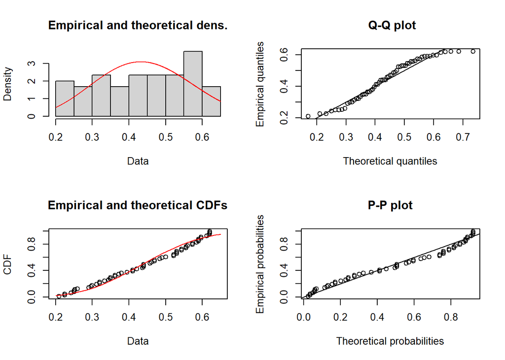

```r
plot(fit_beta_mle)
```

```r
info_df[18, ] = c('beta','MLE',fit_beta_mle$loglik, fit_beta_mle$aic)

# MME
fit_beta_mme = fitdist(time_rep_beta, 'beta', method='mme')
summary(fit_beta_mme)
```

```
## Fitting of the distribution ' beta ' by matching moments
## Parameters :
##        estimate
## shape1 6.544541
## shape2 8.268090
## Loglikelihood:  40.59368   AIC:  -77.18737   BIC:  -72.99868
```

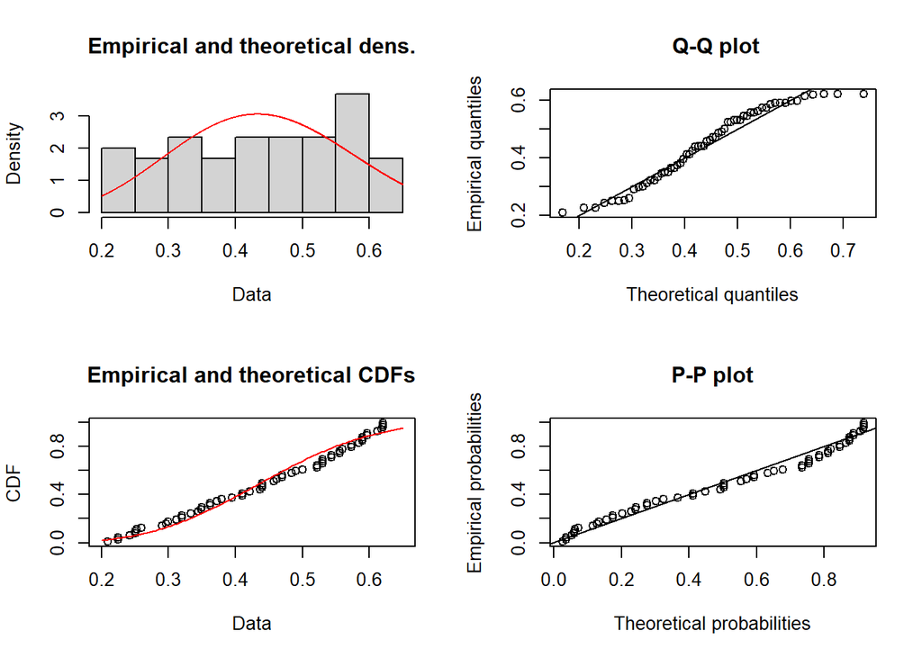

```r
plot(fit_beta_mme)
```

```r
info_df[19, ] = c('beta','MME',fit_beta_mme$loglik, fit_beta_mme$aic)

# QME
fit_beta_qme = fitdist(time_rep_beta, 'beta', method='qme', probs=c(0.5,0.5))
summary(fit_beta_qme)
```

```
## Fitting of the distribution ' beta ' by matching quantiles
## Parameters :
##        estimate
## shape1 6.702873
## shape2 8.167142
## Loglikelihood:  40.41351   AIC:  -76.82701   BIC:  -72.63832
```

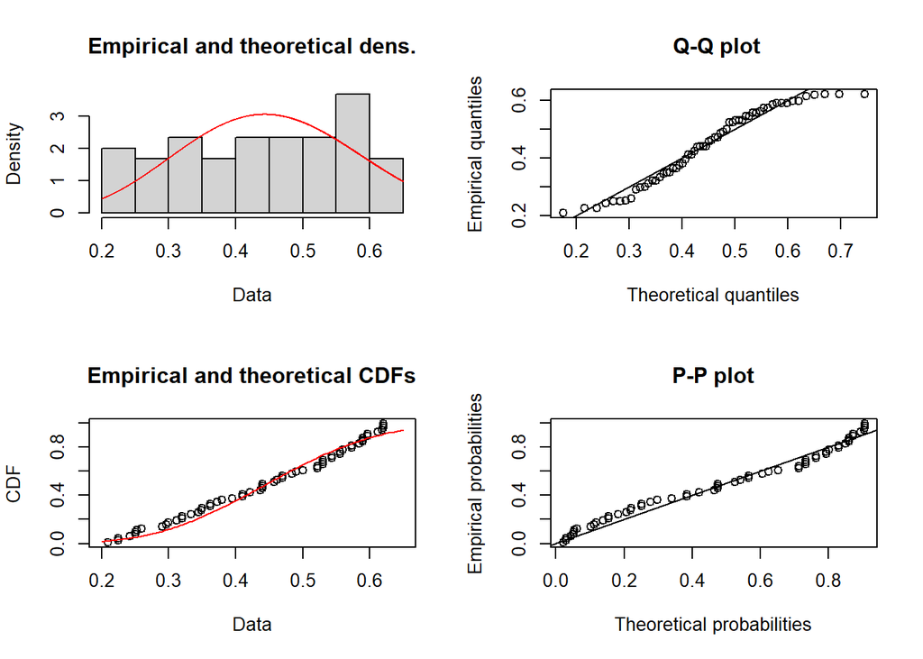

```r
plot(fit_beta_qme)
```

```r
info_df[20, ] = c('beta','QME',fit_beta_qme$loglik, fit_beta_qme$aic)

# MGE
fit_beta_mge = fitdist(time_rep_beta, 'beta', method='mge', gof='KS')
summary(fit_beta_mge)
```

```
## Fitting of the distribution ' beta ' by maximum goodness-of-fit
## Parameters :
##        estimate
## shape1 7.030906
## shape2 8.487984
## Loglikelihood:  40.29323   AIC:  -76.58645   BIC:  -72.39777
```

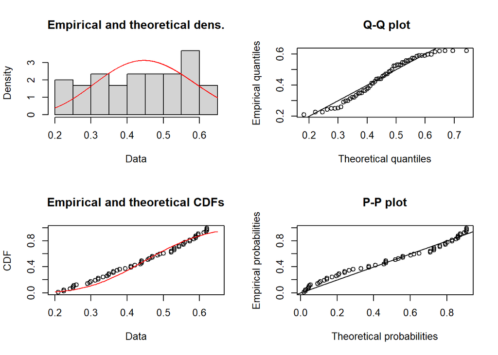

```r
plot(fit_beta_mge)
```

```r
info_df[21, ] = c('beta','MGE KS',fit_beta_mge$loglik, fit_beta_mge$aic)

fit_beta_mge.2 = fitdist(time_rep_beta, 'beta', method='mge', gof='CvM')
summary(fit_beta_mge.2)
```

```
## Fitting of the distribution ' beta ' by maximum goodness-of-fit
## Parameters :
##        estimate
## shape1 5.149031
## shape2 6.347447
## Loglikelihood:  39.43672   AIC:  -74.87344   BIC:  -70.68475
```

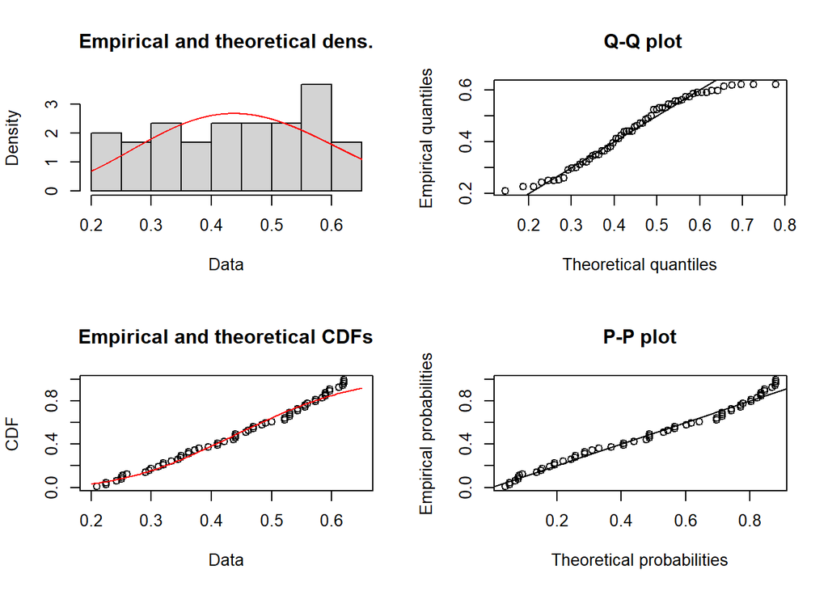

```r
plot(fit_beta_mge.2)
```

```r
info_df[22, ] = c('beta','MGE CvM',fit_beta_mge.2$loglik, fit_beta_mge.2$aic)

fit_beta_mge.3 = fitdist(time_rep_beta, 'beta', method='mge', gof='AD')
summary(fit_beta_mge.3)
```

```
## Fitting of the distribution ' beta ' by maximum goodness-of-fit
## Parameters :
##        estimate
## shape1 5.483825
## shape2 6.831732
## Loglikelihood:  39.94195   AIC:  -75.88389   BIC:  -71.6952
```

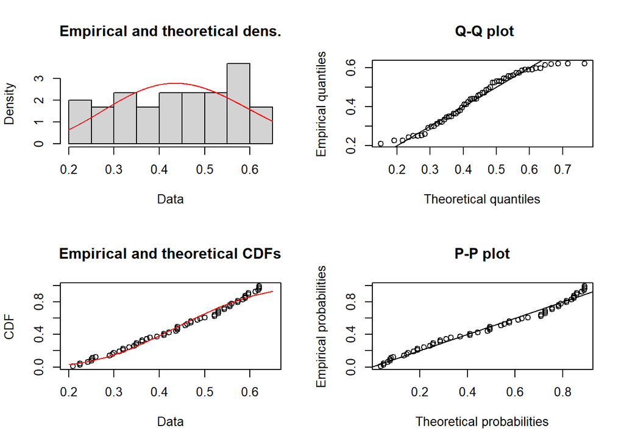

```r
plot(fit_beta_mge.3)
```

```r
info_df[23, ] = c('beta','MGE AD',fit_beta_mge.3$loglik, fit_beta_mge.3$aic)
```

Now that we have stored all the required information in the `info_df` data frame, we can simply output it to compare different methods and different distributions.

```r
info_df
```

```
##      model  method    Log_likelihood               AIC
## 1  weibull     MLE -511.661607095172  1027.32321419034
## 2  weibull     MME -511.990971411679  1027.98194282336
## 3  weibull     QME -511.665566030853  1027.33113206171
## 4  weibull  MGE KS -511.912629512552   1027.8252590251
## 5  weibull MGE CvM -513.227186707635  1030.45437341527
## 6  weibull  MGE AD -512.566002164371  1029.13200432874
## 7    gamma     MLE -514.457695067842  1032.91539013568
## 8    gamma     MME -514.657466136685  1033.31493227337
## 9    gamma     QME -515.428743108187  1034.85748621637
## 10   gamma  MGE KS -515.369433751637  1034.73886750327
## 11   gamma  MGE AD -515.103505182657  1034.20701036531
## 12   lnorm     MLE -516.079010400756  1036.15802080151
## 13   lnorm     MME -516.988130289099   1037.9762605782
## 14   lnorm     QME   -574.2970405833   1152.5940811666
## 15   lnorm  MGE KS -517.739857996554  1039.47971599311
## 16   lnorm MGE CvM -516.740188765648   1037.4803775313
## 17   lnorm  MGE AD -516.672320426231  1037.34464085246
## 18    beta     MLE  40.6027340494813 -77.2054680989627
## 19    beta     MME  40.5936832079002 -77.1873664158003
## 20    beta     QME  40.4135062635942 -76.8270125271885
## 21    beta  MGE KS    40.29322730433 -76.5864546086599
## 22    beta MGE CvM  39.4367176205537 -74.8734352411073
## 23    beta  MGE AD  39.9419468223369 -75.8838936446739
```

To interpret the results, We need to find the distribution with highest log-likelihood value and lowest aic value. As you can see, the best distribution is beta with maximum likelihood estimation method.

Here you can see this distribution fit again which estimates the parameters

```r
fit_beta_mle
```

```
## Fitting of the distribution ' beta ' by maximum likelihood
## Parameters:
##        estimate Std. Error
## shape1 6.678513   1.195520
## shape2 8.466987   1.527763
```

The `fitdistrplus` package also has a function called `descdist` that can check different distributions fitness to our data which as you can see gives the same results.

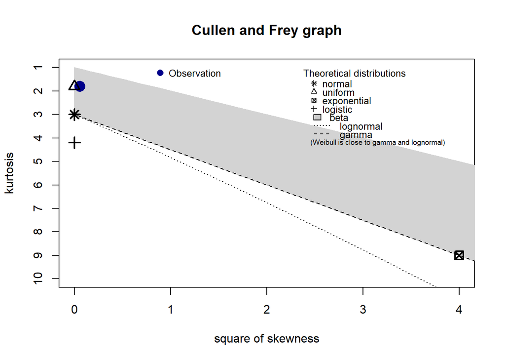

```
## summary statistics
## ------
## min:  2090   max:  6200
## median:  4485
## mean:  4418.217
## estimated sd:  1259.382
## estimated skewness:  -0.2313917
## estimated kurtosis:  1.787182
```

```r
descdist(time_rep)
```

Therefore our chosen model is the beta distribution with parameters 6.678513 as shape1, and 8.4669867 as shape2.

## Failure Probability and Reliability

Failure probability and reliability are complimentary of each other, as $R(t) = 1 - F(t)$. Therefore, 5% failure probability equals 95% reliability and vice versa. In order to find the 5% failure probability we can use the `qbeta` function to find the quantile of the optimal beta distribution that produces 5% failure probability or is reliable 95% of the time.

```r
fail_quant = qbeta(0.05, fit_beta_mle$estimate[1], fit_beta_mle$estimate[2])
```

Remember that with beta distribution, we divided the time points to 10000. We can now multiply this number to reach the time point that produces 95% reliability.

Therefore:

```r
fail_quant = fail_quant*10000
fail_quant
```

```
## [1] 2418.124
```

Therefore at 2418.12 hours, 95% of the systems are still working.